# Titanic Data Analysis

On investigating the data set containing data for 891 passengers on titanic and variable description from kaggle.com, I pose some questions that I am going to analyse in this project.

1) What factors made people more likely to survive? dependent variable: Survival independent variables: gender, class, age, embarking station

2)Which embarking station has most 1st Class passengers and which station has more 2nd and 3rd class passengers?

Apart from this analysis I will also be looking into these questions by exploring the dataset.

3)What was the total survival rate on the ship?

4)How many females were there versus males on the ship?

5)How many 1st class,2nd class and 3rd class passengers were there?

6)Which age group had maximum number of onboard passengers?

Firstly to start my analysis I am loading the csv file containing titanic data into a pandas dataframe.

```python
##Loading the data into a data frame
import numpy as np
import pandas as pd

titanic_data = pd.read_csv('titanic-data.csv')
```

I start investigation the data by displaying the length of the dataset(no. of rows/records) along with unique passengers record. I also check the dataypes and column names of the dataset.

```python
#Investigating the data

print titanic_data['PassengerId'].count()
onboard_passengers = titanic_data['PassengerId'].unique() #keeping note of onboard passengers for later use
print len(onboard_passengers)
titanic_data.info()
```

```
891
891
<class 'pandas.core.frame.DataFrame'>
RangeIndex: 891 entries, 0 to 890
Data columns (total 12 columns):
PassengerId    891 non-null int64
Survived       891 non-null int64
Pclass         891 non-null int64
Name           891 non-null object
Sex            891 non-null object
Age            714 non-null float64
SibSp          891 non-null int64
Parch          891 non-null int64
Ticket         891 non-null object
Fare           891 non-null float64
Cabin          204 non-null object
Embarked       889 non-null object
dtypes: float64(2), int64(5), object(5)
memory usage: 83.6+ KB
```

We can see that the unique passengers number that is 891 matches with the total number of non null records found by using count().So we can say that there are no duplicate or missing records for a single passenger in the dataset.

We notice that there are only 714 records for Age whereas total records are 891. Therefore we have missing values of Age. I will tackle it when using groupby on data as it selects only the non null values and gives the required dataset for my analysis.

Also there are missing cabin records and embarked records as well. Cabin record is not usefull for my analysis so I ignore it. Embarked data will be handled similar to Age data.

```python
#Generic function for seperating out grouped data for onborad and survived passengers and ther Survival rates

def grouping_statistic(df,column):

    #adding up survived per group
    survival_data = df.groupby(column)['Survived'].sum()

    #calculating onboard per group
    onboard_data = df.groupby(column).size()

    #merging the two data
    statistic = pd.concat([survival_data,onboard_data],axis=1)
    statistic = statistic.rename(columns = {0:'Onboard'})    #renaming the column

    #Calculating survival rate for each category
    statistic['Survival_rate'] = statistic.Survived / statistic.Onboard

    return statistic
```

```python
#Creating grouped data for sex,class,age and embarked station and probabilities of survival in each case

gender_statistic = grouping_statistic(titanic_data,'Sex')
class_statistic = grouping_statistic(titanic_data,'Pclass')
embark_statistic = grouping_statistic(titanic_data,'Embarked')

#priting the data achived using probabilty concepts
print gender_statistic
print " "
print class_statistic
print " "
print embark_statistic
```

```
        Survived  Onboard  Survival_rate
Sex
female       233      314       0.742038
male         109      577       0.188908

        Survived  Onboard  Survival_rate
Pclass
1            136      216       0.629630
2             87      184       0.472826
3            119      491       0.242363

          Survived  Onboard  Survival_rate
Embarked
C               93      168       0.553571
Q               30       77       0.389610
S              217      644       0.336957
```

Now we have all the data we require to analyse our questions for gender, class and embarking station. Looking into the next data that we require is Age, which is a continuos data, we find that we need to categorize it into bins.

```python
#Categorizing Age data by range of age(bins)

bins = np.linspace(0, 80, 9)
groups = titanic_data.groupby(pd.cut(titanic_data.Age, bins))

#counting onboard and survived passengers in each group
survival_age_data = groups['Survived'].sum()
onboard_age_data = groups.size()

#merging the two data
age_statistic = pd.concat([survival_age_data,onboard_age_data],axis=1)
age_statistic = age_statistic.rename(columns = {0:'Onboard'})    #renaming the column

#Calculating survival rate for each age group
age_statistic['Survival_rate'] = age_statistic.Survived / age_statistic.Onboard

age_statistic
```

| Age | Survived | Onboard | Survival_rate |
| --- | --- | --- | --- |
| (0, 10] | 38 | 64 | 0.593750 |
| (10, 20] | 44 | 115 | 0.382609 |
| (20, 30] | 84 | 230 | 0.365217 |
| (30, 40] | 69 | 155 | 0.445161 |
| (40, 50] | 33 | 86 | 0.383721 |
| (50, 60] | 17 | 42 | 0.404762 |
| (60, 70] | 4 | 17 | 0.235294 |
| (70, 80] | 1 | 5 | 0.200000 |

Now that we have all the data ready, ie. data grouped by our independent variables and their group wise probabilities. We start to make plots for the data to visualize the results of our analysis.

```python
#Visualization of data

%pylab inline
import matplotlib.pyplot as plt
import seaborn as sns
```

I would like to have some statistics of the data outputted as well as some visualizations of it.

```python
from __future__ import division

#overall survival rate
survival_count = titanic_data['Survived'].sum()
onboard_count = len(onboard_passengers)
total_survival_rate = (survival_count / onboard_count)

print "Total Onboard passengers = {}".format(onboard_count)
print "Total Survived passengers = {}".format(survival_count)
print total_survival_rate
```

```
Total Onboard passengers = 891
Total Survived passengers = 342
0.383838383838
```

```python
# Plot function for a pie plot
def pieplot(values,explode,labels,colors):
    plt.pie(values, explode=explode, labels=labels, colors=colors,
            autopct='%1.1f%%', shadow=True, startangle=100)

    plt.axis('equal')
    plt.show()
```

```
        Survived  Onboard  Survival_rate
Sex
female       233      314       0.742038
male         109      577       0.188908
```

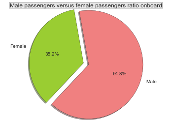

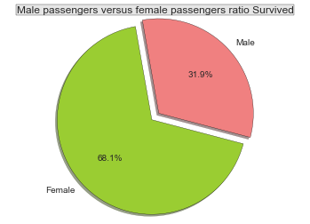

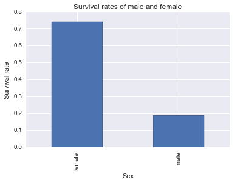

```python
# Data to plot for Gender statistic
labels = 'Female', 'Male'
values = gender_statistic['Onboard']
colors = ['yellowgreen', 'lightcoral']
explode = (0.1, 0)  # explode 1st slice

#Statistics and plot

#Data frame for gender statistics
print gender_statistic

#plot1
title('Male passengers versus female passengers ratio onboard', bbox={'facecolor':'0.9', 'pad':1})
pieplot(values,explode,labels,colors)

#plot2
values = gender_statistic['Survived']
title('Male passengers versus female passengers ratio Survived', bbox={'facecolor':'0.9', 'pad':1})
pieplot(values,explode,labels,colors)

#survival rate bar graph
pl = gender_statistic['Survival_rate'].plot.bar(title='Survival rates of male and female')
pl.set(xlabel='Sex',ylabel='Survival rate')
```

We can see in the pie charts that the female passengers onboard are less versus the male passengers onboard.But survived passengers have more female passengers than male passengers. This makes it quite obvious that female had a higher survival rate which we can see in the next bar graph.

We can see that the survival rate of female passengers were 0.74(74%) while that of male passengers were 0.19(19%).Clearly female passengers had higher survival rate. Thus we can say that female passsengers were more likely to survive.Although it is to be noted that it is merely a correlation between the gender and survival probability and not causation. Thus we can assume that maybe female passengers were given priority at the life boats which gave us this result.

```
        Survived  Onboard  Survival_rate
Pclass
1            136      216       0.629630
2             87      184       0.472826
3            119      491       0.242363
```

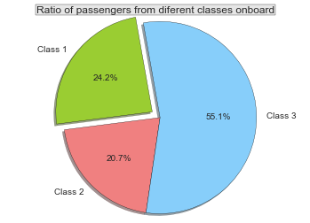

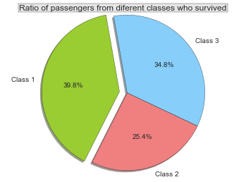

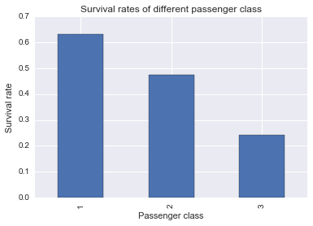

```python
# Data to plot for Class statistic
labels = 'Class 1', 'Class 2', 'Class 3'
values = class_statistic['Onboard']
colors = ['yellowgreen', 'lightcoral','lightskyblue']
explode = (0.1, 0, 0)  # explode 1st slice

#Statistics and plots

#Data frame for passenger class statistics
print class_statistic

#plot1
title('Ratio of passengers from diferent classes onboard', bbox={'facecolor':'0.9', 'pad':1})
pieplot(values,explode,labels,colors)

#plot2
values = class_statistic['Survived']
title('Ratio of passengers from diferent classes who survived', bbox={'facecolor':'0.9', 'pad':1})
pieplot(values,explode,labels,colors)

#survival rate bar graph
pl = class_statistic['Survival_rate'].plot.bar(title='Survival rates of different passenger class')
pl.set(xlabel='Passenger class',ylabel='Survival rate')
```

From the pie plots we can observe that there were more number of passengers from class 3 than class 2 and class 1 onboard. Although of the passengers survived, there are more 1st class passengers than 2nd and 3rd. This gives us an idea that survival rate must be hightest for class 1 passengers. Also we can observe from the charts and the dataframe that among the people who died most of them were from class 3.

We can see from the above bar chart that the rate of survival of the 1st class passengers in highest which is 0.629 (62.9%) and that of the lowest class that is class 3 is the lowest at 0.24(24%) as we expected from the pie charts data. Thus we can say that higher class passengers were more likely to survive. Also this is a correlation and not causation. But we can assume that class 1 passengers might have been given priority at the life boats which resulted it the above statistics.

```
          Survived  Onboard  Survival_rate
Embarked
C               93      168       0.553571
Q               30       77       0.389610
S              217      644       0.336957
```

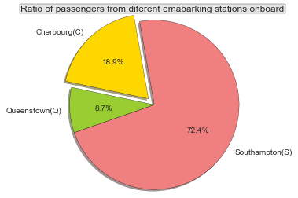

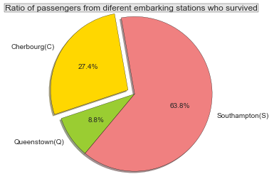

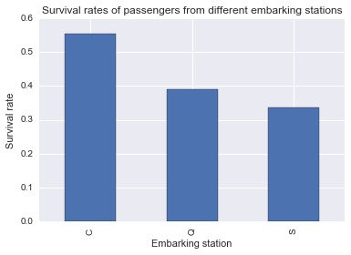

```python
# Data to plot for embarkment station statistic
labels = 'Cherbourg(C)', 'Queenstown(Q)', 'Southampton(S)'
values = embark_statistic['Onboard']
colors = ['gold', 'yellowgreen', 'lightcoral']
explode = (0.1, 0, 0)  # explode 1st slice

#Statistics and plots

#Data frame for passenger class statistics
print embark_statistic

#plot1
title('Ratio of passengers from diferent emabarking stations onboard', bbox={'facecolor':'0.9', 'pad':1})
pieplot(values,explode,labels,colors)

#plot2
values = embark_statistic['Survived']
title('Ratio of passengers from diferent embarking stations who survived', bbox={'facecolor':'0.9', 'pad':1})
pieplot(values,explode,labels,colors)

#survival rate bar graph
pl = embark_statistic['Survival_rate'].plot.bar(title='Survival rates of passengers from different embarking stations')
pl.set(xlabel='Embarking station',ylabel='Survival rate')
```

From the pie plots we can observe that maximum number of passengers onboard as well as survived were from Southampton and least were from Queenstown. In the bar chart we observe that passengers who embarked from Cherbourg station have the highest probability of survival at 0.55(55%) while people who embarked from Southampton have the lowest probability of survival at 0.336(33.6%). Although there were maximum number of passengers onboard as well as survived from Southampton, the survival rate is lowest and the unexpected Cherbourg has the highest survival rate. This is because the number although looks like more for Southampton, the proportion of onboard to survived is less which brings down the survival rate of Southampton, which is a relative measure.

From this result, we can conclude that passengers from Cherbourg were more likely to survive. But we dont know the reason behind it and how is a station of embarkment related to the survival rate. To find this we need to find relation of embarking station with any other possible variables which affects the survival rate, like age, class, etc. I choose to explore the relation of the station with class.

```
Pclass  Embarked
1       C            85
        Q             2
        S           127
2       C            17
        Q             3
        S           164
3       C            66
        Q            72
        S           353
dtype: int64
```

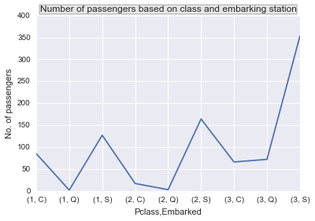

```python
embark_class_relation = titanic_data.groupby(['Pclass','Embarked'])
embark_class_relation = embark_class_relation.size()

print embark_class_relation
title('Number of passengers based on class and embarking station', bbox={'facecolor':'0.9', 'pad':1})
plot_relation = embark_class_relation.plot()
plot_relation.set(ylabel='No. of passengers')
```

From this graph we can observe that most of the passengers boarded from Southampton as we see steep peaks at Southamton data(agrees with results found before). Among them the most population 353 were from class 3 of passengers. This somewhat explains what we observed in the previous graph, that passengers from Southampton were less likely to survive as it had most class 3 passenegers. This compliments the analysis results of our class_statistic data.

```python
#visualizing probability of survival on basis of age

#Data frame for age and statistics
print age_statistic
```

```
          Survived  Onboard  Survival_rate
Age
(0, 10]         38       64       0.593750
(10, 20]        44      115       0.382609
(20, 30]        84      230       0.365217
(30, 40]        69      155       0.445161
(40, 50]        33       86       0.383721
(50, 60]        17       42       0.404762
(60, 70]         4       17       0.235294
(70, 80]         1        5       0.200000
```

```
Mean age statistic
29.6991176471
Median of age
28.0
Minimum age on board
0.42
Maximum age on board
80.0
```

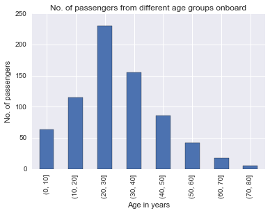

```python
#Bar graph for onboard passengers of different age groups
p1 = age_statistic['Onboard'].plot.bar(title='No. of passengers from different age groups onboard')
p1.set(xlabel='Age in years',ylabel='No. of passengers')

print "Mean age statistic"
print titanic_data['Age'].mean()
print "Median of age"
print titanic_data['Age'].median()
print "Minimum age on board"
print titanic_data['Age'].min()
print "Maximum age on board"
print titanic_data['Age'].max()
```

Here we can see that most passengers on board are from 20-30 age group. The distribution is normal. We have statistic measures of this distribution above the graph. We can also observe that the mean and median are nearly equal and in the bin 20-30 as this is a normal distribution.

```
Mean age statistic
29.6991176471
Median of age
28.0
Minimum age survived
0.42
Maximum age survived
80.0
```

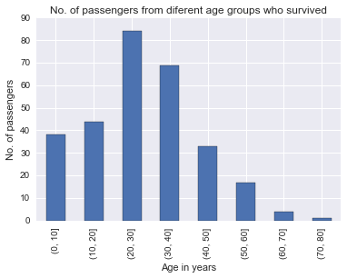

```python
#Bar graph to show no. of passengers survived in each age group

p2 = age_statistic['Survived'].plot.bar(title='No. of passengers from diferent age groups who survived')
p2.set(xlabel='Age in years',ylabel='No. of passengers')

print "Mean age statistic"
print titanic_data['Age'].mean()
print "Median of age"
print titanic_data['Age'].median()
print "Minimum age survived"
print titanic_data['Age'].min()
print "Maximum age survived"
print titanic_data['Age'].max()
```

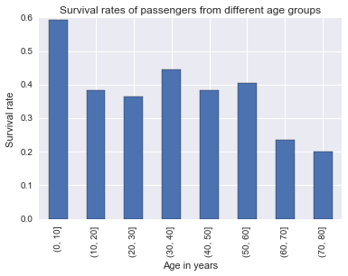

```python
#Bar graph showing survival rate of different age groups

p3 = age_statistic['Survival_rate'].plot.bar(title='Survival rates of passengers from different age groups')
p3.set(xlabel='Age in years',ylabel='Survival rate')
```

We can observe from this graph that this is a positively skewed graph. This means that the probability of survivial of younger aged passengers were more while the probability in the middle region of ages 20-50 are moderate and again that of the higher age groups are least. Thus we can say that passengers of younger age below were more likely to survive. This maybe because children may have been given priority at the life boats. Again this is an assumption as we can prove a correlation but this does not mean a causation.

Conclusion:: In view of the above analysis we can counclude our findings about the data:

1)Children(on basis of age) , women(on basis of gender) and class 1 passengers(on basis of passenger class) were more likely to survive. But this is based solely on a correlation and there may be other lurking variables that could affect each of the gorups results. Such as women might be mostly from the 1st class and 1st class passengers were given priority and hence women show a higher survival rate.

2)The embarkment station also shows a correlation with the survival rate probably due to its correlation with class of a passenger. Again this is a tentative results and we cannot say it with enough proof without other statistical analysis. This is because there might have been other factors affecting this such as age or gender of passngers from a particular embarking station.

3)The overall survival rate of the ship was 0.38 (38%)

4)There were more male on the ship versus female on the ship. But of the survived passengers, there were more female than male passengers.

5)There were most class 3 passengers as compared to class 1 and class 2 passengers. Although the survival rate of class 1 passengers were highest and that of the class 3 passengers the lowest.

6)Maximum onboard passengers were from age group 20-30 years. But maximum survival rate was of children onboard.

Reference List:

https://www.kaggle.com/c/titanic/data

http://pandas.pydata.org/pandas-docs/version/0.18.1/visualization.html

https://pythonspot.com/en/matplotlib-pie-chart/

stackoverflow.com

http://matplotlib.org/1.2.1/examples/pylab_examples/pie_demo.html

https://www.analyticsvidhya.com/blog/2015/05/data-visualization-python/

tutorialspoint.com

google.com

matplotlib documentation

python documentations

http://pandas.pydata.org/pandas-docs/stable/generated/pandas.cut.html